# Analysis of timing of MRCA & copy number gains

## Models of age-incidence curves for sporadic & inherited ccRCC

There is a rich literature of using age-incidence curves for cancer to derive fundamental insights into the dynamics of cancer evolution. What we have learnt in this study is that the evolution of sporadic clear cell kidney cancer appears to follow well-defined and recurrent trajectories. Frequently, it seems the first event is chromosome 3p loss, often with concomitant gains on other chromosomes - this appeors to occur predominantly in childhood or adolescence. The other key event that occurs early in the evolution of sporadic ccRCC is inactivation of the other allele of VHL, typically through point mutation (notwithstanding the role of epigenetic silencing) - this is an obligately early event, because it is both highly recurrent across patients (>75%) and always present on the trunk of the phylogenetic tree.

There are clearly other key steps in the evolution of ccRCC. These include: modulation of the PI3K signalling pathway; TERT up-regulation (often through regulatory mutations); driver mutations in other epigenetic regulators such as PBRM1 and/or SETD2; other structural variations and copy number changes; and clonal expansion of the most recent common ancestor. These other driver mutations typically occur later than chr 3p loss and VHL inactivation (since they are often subclonal) and each occurs with a recurrence rate that is considerably lower (typically <20% patients).

Furthermore, exploring the genomic features of ccRCC that have occurred in the setting of inherited VHL mutations reveals many similarities with sporadic ccRCC, as described by [Fei et al](http://doi.org/10.1038/ncomms11588) and analysed further here. Large-scale chromosomal loss of the other allele of chr 3p is universal. The other driver mutations occur in the same genes and at broadly the same frequencies. The mutation rate is similar to that seen in sporadic cancers, with an almost identical spectrum and linear association with age.

We therefore built Bayesian models of the age-incidence curves for sporadic and inherited ccRCC. The first step is to interpret the published age-incidence figures. The age-incidence curves for sporadic clear cell RCC come from Cancer Research UK and represent age-specific annual incidence figures per 100,000 population, banded in 5-year groups. The figures for inherited vHL disease are Kaplan-Meier curves derived from [Ong et al](http://doi.org/10.1002/humu.20385). The second step is to take draws of cohorts of individual patients (or censored non-patients) from the published curves. These then represent the data that is fitted by the Bayesian model.

```r
NUM.VHL.CASES <- 100
NUM.SPORADIC <- 1000

# Read in age-incidence curves
vhl.penetrance <- read.table("../../data/sampler_data/Penetrance of RCC in vHL disease.txt", sep="\t", header=TRUE, stringsAsFactors = FALSE)
cruk.sporadic.incidence <- read.table("../../data/sampler_data/Age-incidence of sporadic RCC.txt", sep="\t", header=TRUE, stringsAsFactors = FALSE)

# Generate random sample of NUM.VHL.CASES age-incidences and censoring values for inherited RCCs
# Note that the vhl.penetrance data are cumulative Kaplan-Meier incidences and occur in nearly yearly increments
vhl.penetrance <- rbind(vhl.penetrance, c(63,1))
vhl.penetrance$lower <- c(0, vhl.penetrance$Penetrance[1:(nrow(vhl.penetrance)-1)])

vhl.incidence <- data.frame(Type = rep("vHL", NUM.VHL.CASES), stringsAsFactors = FALSE)
draws <- runif(n = NUM.VHL.CASES, min=0, max=1)
vhl.incidence$Age <- sapply(draws, function(i,x) x$Age[x$lower <= i & x$Penetrance > i], x=vhl.penetrance)
vhl.incidence$Censored <- as.double(vhl.penetrance$lower[nrow(vhl.penetrance)] <= draws)

# Generate random sample of NUM.CASES age-incidences and censoring values for sporadic RCCs
# Note that the cruk.sporadic.incidence data are age-incidence rates per year per 100,000 population in 5 year blocks
cruk.sporadic.incidence$Rate.per.year <- (cruk.sporadic.incidence$Male.Rates + cruk.sporadic.incidence$Female.Rates)/2/100000
cruk.by.year <- data.frame(Age = 1:95,
                           Incidence = rep(cruk.sporadic.incidence$Rate.per.year, each=5))
cruk.by.year$Penetrance <- 1 - cumprod(1-cruk.by.year$Incidence)
cruk.by.year <- rbind(cruk.by.year, c(95, 1, 1))
cruk.by.year$lower <- c(0, cruk.by.year$Penetrance[1:(nrow(cruk.by.year)-1)])


sporadic.incidence <- data.frame(Type = rep("Sporadic", NUM.SPORADIC), stringsAsFactors = FALSE)
draws <- runif(n = NUM.SPORADIC, min=0, max=1)
sporadic.incidence$Age <- sapply(draws, function(i,x) x$Age[x$lower <= i & x$Penetrance > i], x=cruk.by.year)
sporadic.incidence$Censored <- as.double(cruk.by.year$lower[nrow(cruk.by.year)] <= draws)
```

### Bayesian model of age-incidence curves

The primary question of interest is how large is the clone(s) carrying 3p loss during the development of sporadic kidney cancer. The intuition here is a twist on the approach Knudson took in deriving his [two-hit model of retinoblastoma incidence](http://doi.org/10.1073/pnas.68.4.820). Essentially, he takes the known number of retinal ganglion cells and age-incidence of inherited retinoblastomas to derive the mutation rate in the (then unknown) predisposition gene. He then shows that the age-incidence curves for sporadic retinoblastoma fit with a two-mutation model using the estimated mutation rate. In our situation, we know the mutation rate (and target gene) very accurately - indeed, in the preceding section, we estimate the *VHL* driver mutation rate per clone per year. From the difference in age-incidence curves between *VHL* carriers and sporadic kidney cancers, and the known *VHL* driver mutation rate per cell per year, we can estimate how many cells that are susceptible to initiating ccRCC carry chr 3p loss during adulthood.

The major assumption in this approach is that the evolution of sporadic kidney cancers and inherited ccRCC in vHL patients is identical except for the need to inactivate *VHL* as a somatic event in the sporadic cases. The broad concept for modelling the age-incidence curves is to treat sporadic ccRCC as the sum of three independent waiting times (time to 3p loss; time from 3p loss to *VHL* inactivation; time from biallelic *VHL* loss to diagnosed kidney cancer). We treat ccRCC in carriers of VHL as the sum of two independent waiting times, with the same distribution as in sporadic cases (time to 3p loss; time from 3p loss (that is, biallelic *VHL* inactivation) to diagnosed kidney cancer).

In more technical detail, we let \(Y_{i,spor}\) denote the age of incidence (in years) of patient \(i\) with sporadic ccRCC, and \(Y_{i,vHL}\) the age of incidence of ccRCC in patients with von Hippel-Lindau disease, we have: \[ \begin{align} Y_{i,spor} &= Z_1 + Z_2 + Z_3\ Y_{i,vHL} &= Z_1 + Z_3, \end{align} \] where \(Z_1\) is the time to 3p loss; \(Z_2\) is the time to *VHL* inactivation; and \(Z_3\) is the time from (biallelic) *VHL* loss to kidney cancer diagnosis. Clearly, we do not observe all waiting times, since ~20% of vHL cases do not develop ccRCC and the vast majority on non-carriers do not. Thus, there will be censoring of the sum of waiting times for many individuals, which we handle by data augmentation.

We model these waiting times with the gamma distribution for \(Z_1\) and \(Z_3\) and the exponential distribution for \(Z_2\). That is: \[ \begin{align} Z_1 &\sim \Gamma(\alpha_1, \beta_1)\ Z_2 &\sim \text{Exp}(\lambda)\ Z_3 &\sim \Gamma(\alpha_3, \beta_3), \end{align} \] where \(\lambda = n\mu\), with \(n\) as the number of cells in the clone after chr 3p loss and \(\mu\) as the *VHL* driver mutation rate per cell per year. We use the conjugate prior: \(\lambda \sim \Gamma(0.01,0.01)\). The parameters, \(\alpha_1, \beta_1, \alpha_3, \beta_3\), we model as coming from the conjugate prior to the gamma distribution: \[(\alpha, \beta) \propto \frac{p^{\alpha-1}e^{-\beta q}}{\Gamma(\alpha)^r\beta^{-\alpha s}},\] where p, q, r and s are the hyperparameters of the conjugate prior. For \(\alpha_3\) and \(\beta_3\), we use uninformative hyperparameters (\(p_3=q_3=r_3=s_3=1\)), but for \(\alpha_1\) and \(\beta_1\), we put an informative prior distilled from the estimated ages of chromosome 3p loss. That is,

\[p_1 = \prod_i{x_{3p,i}}~;~~q_1 = \sum_i{x_{3p,i}}~;~~ r_1 = s_1 = n_{3p}~,\]

where \(x_{3p,i}, i=1,…,n_{3p}\) are the estimated ages at which chr 3p loss occurred from patients with informative t(3;-) translocations.

We take draws from the posterior distribution using a Gibbs sampler. We use 50,000 iterations with the first 20,000 being treated as burn-in. The steps involved are as follows:

1. **Update \(z_{i,1}\) and \(z_{i,3}\) for vHL patients who were not censored.** Since patients who were not censored have an exact observed age of incidence, \(y_i\), we must take draws such that \(z_{i,1} + z_{i,3} = y_i\). We do this by using a Metropolis-Hastings approach where the proposal distribution is a Dirichlet distribution, scaled to the age of incidence. That is, \[(z_{i,1}^{(*)},z_{i,3}^{(*)}) \sim y_i~.~\text{Dir}\left(\frac{\kappa~z_{i,1}^{(j-1)}}{z_{i,1}^{(j-1)}+z_{i,3}^{(j-1)}},~ \frac{\kappa~z_{i,3}^{(j-1)}}{z_{i,1}^{(j-1)}+z_{i,3}^{(j-1)}}\right),\] where \(\kappa\) is a scaling factor tuned by the user to optimise the acceptance ratio of the M-H algorithm. The importance ratio for the M-H algorithm is therefore: \[ \begin{align} Q_i &= \frac{f({\bf{z_i^{(j-1)}}}|{\bf{z_i^{(*)}}})}{f({\bf{z_i^{(*)}}}|{\bf{z_i^{(j-1)}}})}.\frac{P({\bf{z_i^{(*)}}}|{\bf{z_i^{(j-1)}}}, \alpha_1^{(j-1)}, \beta_1^{(j-1)}, \alpha_3^{(j-1)}, \beta_3^{(j-1)}))}{P({\bf{z_i^{(j-1)}}}|{\bf{z_i^{(*)}}}, \alpha_1^{(j-1)}, \beta_1^{(j-1)}, \alpha_3^{(j-1)}, \beta_3^{(j-1)})}\ & \ &= \frac{f({\bf{z_i^{(j-1)}}}|{\bf{z_i^{(*)}}})}{f({\bf{z_i^{(*)}}}|{\bf{z_i^{(j-1)}}})}. \left( \frac{z_{i,1}^{(*)}}{z_{i,1}^{(j-1)}} \right)^{\alpha_1^{(j-1)}-1}. \left( \frac{z_{i,3}^{(*)}}{z_{i,3}^{(j-1)}} \right)^{\alpha_3^{(j-1)}-1}. e^{-\beta_1^{(j-1)}(z_{i,1}^{(*)}-z_{i,1}^{(j-1)})-\beta_3^{(j-1)}(z_{i,3}^{(*)}-z_{i,3}^{(j-1)})} \end{align} \] This is the accepted or reject in the usual way.
2. **Update of \(z_{i,1}\) and \(z_{i,3}\) for vHL patients who were censored.** Here, we know only the lower bound on the \(y_i\), so we sample these using rejection sampling. That is, we take draws of \(z_{i,1}^{(*)} \sim \Gamma \left(\alpha_1^{(j-1)}, \beta_1^{(j-1)} \right)\) and \(z_{i,3}^{(*)} \sim \Gamma \left(\alpha_3^{(j-1)}, \beta_3^{(j-1)} \right)\) until \(z_{i,1}^{(*)} + z_{i,3}^{(*)}\) is greater than the age of censoring.
3. **Update of \(z_{i,1}\), \(z_{i,2}\) and \(z_{i,3}\) for sporadic ccRCC patients who were not censored.** We apply the same approach as in step 1, using an analogous three parameter Dirichlet proposal distribution.
4. **Update of \(z_{i,1}\), \(z_{i,2}\) and \(z_{i,3}\) for sporadic ccRCC patients who were censored.** We apply the analogous rejection sampling approach as used in step 2.
5. **Update of \(\alpha_1\), \(\beta_1\), \(\alpha_3\) and \(\beta_3\) from cojugate prior.** Given the (informative) hyperparameters \(p_1, q_1, r_1\text{ and }s_1\) for the conjugate prior for \(\alpha_1\) and \(\beta_1\), we have: \[f(\alpha_1, \beta_1 | p_1, q_1, r_1, s_1,{\bf{z_1}}) \propto \frac{\left(p_1\prod_iz_i \right)^{\alpha_1}~.~e^{-\beta_1(q_1+\sum_iz_i)}}{\Gamma(\alpha_1)^{r_1+n}~.~\beta_1^{-\alpha_1(s_1+n)}}\] We sample from this posterior using Metropolis-Hastings with the proposal distributions as independent gamma variables: \(\alpha_1^{(*)} \sim \Gamma \left(\gamma \alpha_1^{(j-1)}, \gamma \right),~~\beta_i^{(*)} \sim \Gamma \left(\gamma \beta_1^{(j-1)},\gamma \right),\) where \(\gamma\) is a scaling factor defined by the user to optimise the acceptance / rejection ratio. The importance ratio is calculated, and the proposed values, \(\alpha_1^{(*)}\) and \(\beta_1^{(*)}\), acceoted or rejected in the usual way. The same approach is applied to updating \(\alpha_3\) and \(\beta_3\).
6. **Update of \(\lambda\).** We take draws directly from the posterior: \(\lambda^{(j)} \sim \Gamma \left( 0.01+n_{spor}, 0.01+\sum_i z_{i,2}^{(j)} \right)\).
7. **Draws from posterior distribution of ages of incidence under different clone sizes.** We can also take draws of alternative \(z_{i,2}\) values if the clone size were different. That is, we draw \(z_{i,2}^{(j)} \sim \text{Exp} (\rho \lambda^{(j)})\) and add to \(z_{i,1}^{(j)}+z_{i,3}\){(j)}$ to generate an alternative age of incidence.

There are a few points of note in this implementation of the model. First, we assume independence of the waiting times. If, for example, there is clone-to-clone variation in the mutation rate, this assumption may not be entirely valid, since \(Z_2\) would potentially be correlated with \(Z_3\). However, it is unclear how much clone-to-clone variation there is in mutation rate among kidney cells and how much inter-individual variation. Second, we assume that the clone size is broadly constant after chromosome 3p loss. That is, the clone expands rapidly to a steady-state number, at which stage it plateaus. In fact, given the relatively small number of cells estimated in the clones, this is probably a reasonable assumption. Third, we do make the assumption that the order of events is chromosome 3p loss, followed by *VHL* point mutation, followed by other driver mutations, clonal expansion and diagnosis. Given that we are estimating a clone size of several hundred cells after chromosome 3p loss, it is statistically much more likely that the *VHL* mutation will occur after this clonal expansion than in the one cell before chr 3p loss (inherent in this is the assumption that the rate of chromosome 3p loss through, for example, chromothripsis involving chromosomes 3p and 5q is much lower than that of *VHL* driver point mutations).

```r
# Generate MLE estimators for gamma distribution of age of 3p loss
ages.3p.loss <- t3_5.abs.time$triploid.est
s <- log(mean(ages.3p.loss)) - mean(log(ages.3p.loss))
alpha.1.est <- (3 - s + sqrt((s-3)^2 + 24*s)) / (12*s)
beta.1.est <- alpha.1.est / mean(ages.3p.loss)

alpha.1.est
```

[1] 4.231739

```r
beta.1.est
```

[1] 0.3009428

```r
# Set-up the Gibbs sampler
rcc.age.gs <- function(spor.ages, vhl.ages, chr3p.ages, d.sf, g.sf, iterations, alpha.1.init = alpha.1.est, beta.1.init = beta.1.est, lambda.init=1e-3) {
  # Gibbs sampler for the three waiting times model of RCC development
  # spor.ages is a data.frame of ages of incidence / censoring of sporadic RCC
  # vhl.ages is a data.frame of ages of incidence / censoring of RCC in vHL disease
  # chr3p.ages is a vector of ages of incidence of chr3p loss inferred from t(3;-) cases
  # d.sf is the scaling factor for the Dirichlet proposal distribution - larger values mean smaller jumps
  # g.sf is the scaling factor for the Gamma proposal distribution - larger values mean smaller jumps
  # iterations is the number of iterations of the Gibbs sampler

  # Split age-incidences into censored and non-censored
  spor.ages.cens.T <- spor.ages[spor.ages$Censored == 1,]
  spor.ages.cens.F <- spor.ages[spor.ages$Censored == 0,]
  vhl.ages.cens.T <- vhl.ages[vhl.ages$Censored == 1,]
  vhl.ages.cens.F <- vhl.ages[vhl.ages$Censored == 0,]

  age.of.censoring.vhl <- unique(vhl.ages.cens.T$Age)
  age.of.censoring.sporadic <- unique(spor.ages.cens.T$Age)
  if (length(c(age.of.censoring.vhl,age.of.censoring.sporadic)) != 2) {stop("Age at censoring should be unique")}

  # Set up initial values and hyperparameters
  alpha.1 <- beta.1 <- alpha.3 <- beta.3 <- accepted.1 <- accepted.3 <- lambda <- rep(NA, iterations)
  alpha.1[1] <- alpha.1.init
  beta.1[1] <- beta.1.init

  alpha.3[1] <- 20
  beta.3[1] <- 0.5

  accepted.1[1] <- accepted.3[1] <- TRUE # Acceptance rates for the M-H algorithm for the Z1 & Z3 gamma parameters

  lambda[1] <- lambda.init # The VHL driver mutation rate per year

  # Values for hyperparameters on gamma distribution for Z1
  log.hyperparameter.p.1 <- sum(log(chr3p.ages))
  hyperparameter.q.1 <- sum(chr3p.ages)
  hyperparameter.r.1 <- hyperparameter.s.1 <- length(chr3p.ages)

  # Set up matrices of waiting times
  vhl.wait.times.cens.F <- array(data = NA, dim=c(nrow(vhl.ages.cens.F), 2, iterations))
  vhl.wait.times.cens.F[,1,1] <- rep(15, nrow(vhl.ages.cens.F))
  vhl.wait.times.cens.F[,2,1] <- vhl.ages.cens.F$Age - 15

  vhl.wait.times.cens.T <- array(data = NA, dim=c(nrow(vhl.ages.cens.T), 2, iterations))
  vhl.wait.times.cens.T[,1,1] <- rep(15, nrow(vhl.ages.cens.T))
  vhl.wait.times.cens.T[,2,1] <- vhl.ages.cens.T$Age - 5

  spor.wait.times.cens.F <- array(data = NA, dim=c(nrow(spor.ages.cens.F), 3, iterations))
  spor.wait.times.cens.F[,1,1] <- rep(15, nrow(spor.ages.cens.F))
  spor.wait.times.cens.F[,2,1] <- (spor.ages.cens.F$Age - 15) / 2
  spor.wait.times.cens.F[,3,1] <- (spor.ages.cens.F$Age - 15) / 2

  spor.wait.times.cens.T <- array(data = NA, dim=c(nrow(spor.ages.cens.T), 3, iterations))
  spor.wait.times.cens.T[,1,1] <- rep(15, nrow(spor.ages.cens.T))
  spor.wait.times.cens.T[,2,1] <- (spor.ages.cens.T$Age - 5) / 2
  spor.wait.times.cens.T[,3,1] <- (spor.ages.cens.T$Age - 5) / 2

  sampled.wait.times.less0 <- sampled.wait.times.less0.25 <- sampled.wait.times.less0.5 <- sampled.wait.times.less0.75 <- matrix(NA, nrow=nrow(spor.ages), ncol=iterations)

  # Run the Gibbs sampler
  for (iter in 2:iterations) {

    ##########################################################
    # Update of Z1 and Z3 for VHL cases that were not censored
    # Done by Metropolis-Hastings with proposal distribution as Dirichlet centred on curr Z1 & Z3 and scaled
    # Choice of Dirichlet enforces constraint that waiting times must sum to the age of incidence (with scaling)
    vhl.wait.times.cens.F[,,iter] <- censored.wait.times.GS(vhl.wait.times.cens.F[,,iter-1], d.sf, c(alpha.1[iter-1], alpha.3[iter-1]), c(beta.1[iter-1], beta.3[iter-1]))

    ######################################################
    # Update of Z1 and Z3 for vHL cases that were censored
    # Done with rejection sampling
    counter <- 1
    while(counter <= nrow(vhl.ages.cens.T)) {
      z1.proposed <- rgamma(1, alpha.1[iter-1], beta.1[iter-1])
      z3.proposed <- rgamma(1, alpha.3[iter-1], beta.3[iter-1])
      age.proposed <- z1.proposed + z3.proposed

      if (age.proposed > age.of.censoring.vhl) {
        vhl.wait.times.cens.T[counter,1,iter] <- z1.proposed
        vhl.wait.times.cens.T[counter,2,iter] <- z3.proposed
        counter <- counter+1
      }
    }

    ###################################################################
    # Update of Z1, Z2 and Z3 for sporadic cases that were not censored
    # Done by Metropolis-Hastings with proposal distribution as Dirichlet centred on curr Z1, Z2 & Z3 and scaled
    # Choice of Dirichlet enforces constraint that waiting times must sum to the age of incidence (with scaling)
    spor.wait.times.cens.F[,,iter] <- censored.wait.times.GS(spor.wait.times.cens.F[,,iter-1], d.sf, c(alpha.1[iter-1], 1, alpha.3[iter-1]), c(beta.1[iter-1], lambda[iter-1], beta.3[iter-1]))

    ##########################################################
    # Update of Z1, Z2 and Z3 for vHL cases that were censored
    # Done with rejection sampling
    counter <- 1
    while(counter <= nrow(spor.ages.cens.T)) {
      z1.proposed <- rgamma(1, alpha.1[iter-1], beta.1[iter-1])
      z2.proposed <- rexp(1, lambda[iter-1])
      z3.proposed <- rgamma(1, alpha.3[iter-1], beta.3[iter-1])
      age.proposed <- z1.proposed + z2.proposed + z3.proposed

      if (age.proposed > age.of.censoring.sporadic) {
        spor.wait.times.cens.T[counter,1,iter] <- z1.proposed
        spor.wait.times.cens.T[counter,2,iter] <- z2.proposed
        spor.wait.times.cens.T[counter,3,iter] <- z3.proposed
        counter <- counter+1
      }
    }

    ##############################################
    # Update age-incidence distribution parameters
    update.1 <- gamma.parameter.GS(alpha.1[iter-1], beta.1[iter-1], log.hyperparameter.p.1, hyperparameter.q.1, hyperparameter.r.1, hyperparameter.s.1, c(vhl.wait.times.cens.T[,1,iter], vhl.wait.times.cens.F[,1,iter]), g.sf)
    alpha.1[iter] <- update.1[1]
    beta.1[iter] <- update.1[2]
    accepted.1[iter] <- update.1[3]
```

```r
    update.3 <- gamma.parameter.GS(alpha.3[iter-1], beta.3[iter-1], 0,1,1,1, c(vhl.wait.times.cens.T[,2,iter], vhl.wait.times.cens.F[,2,iter]), g.sf)
    alpha.3[iter] <- update.3[1]
    beta.3[iter] <- update.3[2]
    accepted.3[iter] <- update.3[3]

    # Update rate of VHL driver mutations contributing to Z2
    # Taken from conjugate prior to the exponential (ie gamma) with uninformative priors
    lambda[iter] <- rgamma(1, shape = 0.01 + length(c(spor.wait.times.cens.F[,2,iter], spor.wait.times.cens.T[,2,iter])), rate = 0.01 + sum(c(spor.wait.times.cens.F[,2,iter], spor.wait.times.cens.T[,2,iter])))

    # Sample alternate waiting times for clones of different sizes
    sampled.wait.times.less0[,iter] <- sample.alternate.wait.times(spor.wait.times.cens.F[,,iter], spor.wait.times.cens.T[,,iter], lambda[iter], 1)
    sampled.wait.times.less0.25[,iter] <- sample.alternate.wait.times(spor.wait.times.cens.F[,,iter], spor.wait.times.cens.T[,,iter], lambda[iter], 0.75)
    sampled.wait.times.less0.5[,iter] <- sample.alternate.wait.times(spor.wait.times.cens.F[,,iter], spor.wait.times.cens.T[,,iter], lambda[iter], 0.5)
    sampled.wait.times.less0.75[,iter] <- sample.alternate.wait.times(spor.wait.times.cens.F[,,iter], spor.wait.times.cens.T[,,iter], lambda[iter], 0.25)

    # print(lambda[iter])
  }

  return(list(alpha.1=alpha.1, beta.1=beta.1, alpha.3=alpha.3, beta.3=beta.3, accepted.1=accepted.1, accepted.3=accepted.3, vhl.wait.times.cens.F=vhl.wait.times.cens.F, vhl.wait.times.cens.T=vhl.wait.times.cens.T, spor.wait.times.cens.T=spor.wait.times.cens.T, spor.wait.times.cens.F=spor.wait.times.cens.F, lambda=lambda, sampled.wait.times.less0=sampled.wait.times.less0, sampled.wait.times.less0.25=sampled.wait.times.less0.25, sampled.wait.times.less0.5=sampled.wait.times.less0.5, sampled.wait.times.less0.75=sampled.wait.times.less0.75))
}

######################################################################
censored.wait.times.GS <- function(curr.WT, d.sf, alphas, betas) {
  # Function to provide updates of estimated waiting times for censored cases (ie observed ages of incidence)
  # Done by Metropolis-Hastings with proposal distribution as Dirichlet centred on curr Z1, Z2 & Z3 and scaled
  # Choice of Dirichlet enforces constraint that waiting times must sum to the age of incidence (with scaling)
  # curr.WT is matrix of the current estimates of waiting times
  # d.sf is the scaling factor for the Dirichlet proposal distribution
  # alphas is a vector of the current alpha values for the gamma distributions of waiting times
  # betas is a vector of the current beta values for the gamma distributions of waiting times

  # Generate proposed ages
  proposal <- t(sapply(1:nrow(curr.WT),
                            function(i,x) rdirichlet(1, d.sf * x[i,] / sum(x[i,])),
                            x=curr.WT))
  obs.ages <- rowSums(curr.WT)
  proposal.scaled <- proposal * obs.ages

  # Calculate importance ratios
  log.proposal.dist.ratio <- ddirichlet(curr.WT / obs.ages, d.sf * proposal, log=TRUE) -
      ddirichlet(proposal, d.sf * curr.WT / obs.ages, log=TRUE)

  log.density.ratio <- rowSums( t((alphas-1) * t(log(proposal.scaled) - log(curr.WT)) - betas * t(proposal.scaled - curr.WT)) )

  importance.ratio <- exp(log.proposal.dist.ratio + log.density.ratio)

  if (!all(!is.na(importance.ratio))) {
    importance.ratio[is.na(importance.ratio)] <- 0
  }

  draws <- runif(n=nrow(curr.WT))
  curr.WT[draws < importance.ratio,] <- proposal.scaled[draws < importance.ratio,]
  return(curr.WT)
}

######################################################################
gamma.parameter.GS <- function(curr.alpha, curr.beta, log.hyper.p, hyper.q, hyper.r, hyper.s, x, gamma.sf) {
  # Function to return updates on gamma parameters from its conjugate prior
  # curr.alpha and curr.beta are the current values of the alpha and beta parameters
  # log.hyper.p, hyper.q, hyper.r and hyper.s are hyperparameters for the conjugate prior for curr.alpha & curr.beta
  # x is a vector of the data values
  # gamma.sf is the scaling factor for the M-H algorithm

  # Up-date alpha & beta from the conjugate prior
  # Due to the unnormalised nature of the conjugate, we sample using Metropolis-Hastings since the normalisation factor will cancel out
  # Use independent gamma proposal distributions for alpha and beta
  alpha.proposed <- rgamma(n=1, curr.alpha * gamma.sf, gamma.sf)
  beta.proposed <- rgamma(n=1, curr.beta * gamma.sf, gamma.sf)

  proposal.dist.ratio <- dgamma(x = curr.alpha, shape = alpha.proposed * gamma.sf, rate = gamma.sf) *
    dgamma(x = curr.beta, shape = beta.proposed * gamma.sf, rate = gamma.sf) /
    dgamma(x = alpha.proposed, shape = curr.alpha * gamma.sf, rate = gamma.sf) /
    dgamma(x = beta.proposed, shape = curr.beta * gamma.sf, rate = gamma.sf)

  log.post.p <- log.hyper.p + sum(log(x))
  post.q <- hyper.q + sum(x)
  post.r <- hyper.r + length(x)
  post.s <- hyper.s + length(x)

  log.density.ratio <- (alpha.proposed - curr.alpha) * log.post.p -
    post.q * (beta.proposed - curr.beta) -
    post.r * (lgamma(alpha.proposed) - lgamma(curr.alpha)) +
    post.s * (alpha.proposed * log(beta.proposed) - curr.alpha * log(curr.beta))

  importance.ratio <- proposal.dist.ratio * exp(log.density.ratio)
  if (runif(n=1) < importance.ratio) {
    new.alpha <- alpha.proposed
    new.beta <- beta.proposed
    accepted <- TRUE
  } else {
    new.alpha <- curr.alpha
    new.beta <- curr.beta
    accepted <- FALSE
  }

  return(c(new.alpha, new.beta, accepted))
}

######################################################################
sample.alternate.wait.times <- function(WT.cens.F, WT.cens.T, lambda, lambda.fraction) {
  # Function to sample alternate wait times as if number of cells were lambda.fraction x current estimate
  WT.cens.F[,2] <- rexp(nrow(WT.cens.F), rate = lambda.fraction * lambda)
  WT.cens.T[,2] <- rexp(nrow(WT.cens.T), rate = lambda.fraction * lambda)
  return(rowSums(rbind(WT.cens.F, WT.cens.T)))
}
```

```r
######################################################################
# Run the Gibbs sampler
```

### Checking convergence of MCMC chain

We check some convergence and mixing plots for the \(\alpha\) and \(\beta\) estimates. They show rather slow mixing for alpha_1 and beta_1. This is perhaps not surprising since the information for the \(Z_1\) waiting time is somewhat confounded with the \(Z_3\) waiting time, except through the prior information provided from the timings of t(3;-) translocations. Nonetheless, we have experimented with many different starting points for these values, and the posterior always converges well to the distribution shown here.

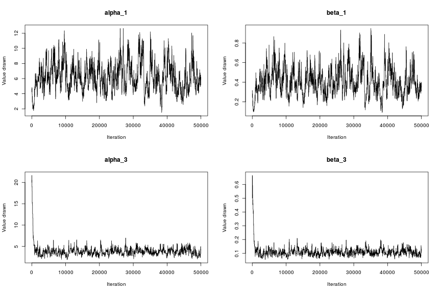

```r
load("age_inc_gs.RData")

par(mfrow=c(2,2))
plot(1:rcc.iters, age.inc.gs[[1]], type="l", xlab="Iteration", ylab="Value drawn", main = "alpha_1")
plot(1:rcc.iters, age.inc.gs[[2]], type="l", xlab="Iteration", ylab="Value drawn", main = "beta_1")
plot(1:rcc.iters, age.inc.gs[[3]], type="l", xlab="Iteration", ylab="Value drawn", main = "alpha_3")
plot(1:rcc.iters, age.inc.gs[[4]], type="l", xlab="Iteration", ylab="Value drawn", main = "beta_3")
```

### Exploring outputs from Bayesian model

The key question of interest in this modelling are to establish the potential number of cells that carry chr 3p loss without having the other *VHL* allele mutated. The MCMC draws from the posterior distribution converge and mix very well as shown in the first plot below. As can be seen from the histogram in the second plot, the posterior distribution suggests that the number of cells in the kidney that carry chromosome 3p loss before the other *VHL* allele is mutated is only in the hundreds. That is, there is not a massive clonal expansion after the initiating event.

The other question of interest is to model what would happen to the age-incidence curves for sporadic kidney cancer if we had a treatment that could kill a fraction of cells at the chr 3p loss stage. This is shown in the bottom three plots below. It seems that we could halve the incidence cancer with a treatment in early adulthood that reduced the number of cells with chr 3p loss by 50%.

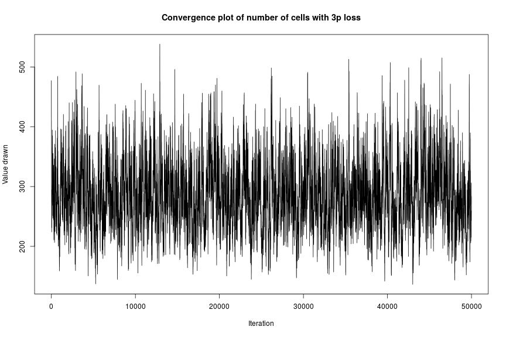

```r
par(mfrow=c(1,1))
plot(1:rcc.iters, age.inc.gs[[11]] / vhl.driver.mutation.rate, type="l", xlab="Iteration", ylab="Value drawn", main = "Convergence plot of number of cells with 3p loss")
```

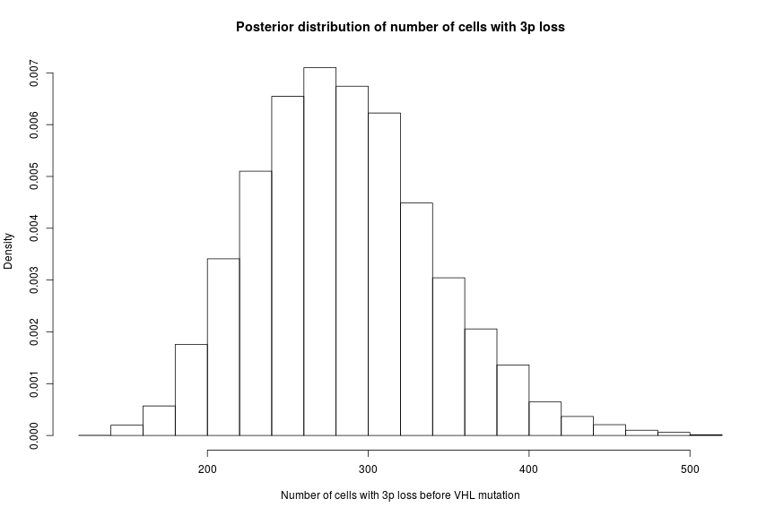

```r
hist(age.inc.gs[[11]][rcc.burn.in:rcc.iters] / vhl.driver.mutation.rate, breaks=20, probability = TRUE, xlab = "Number of cells with 3p loss before VHL mutation", ylab="Density", main = "Posterior distribution of number of cells with 3p loss")
```

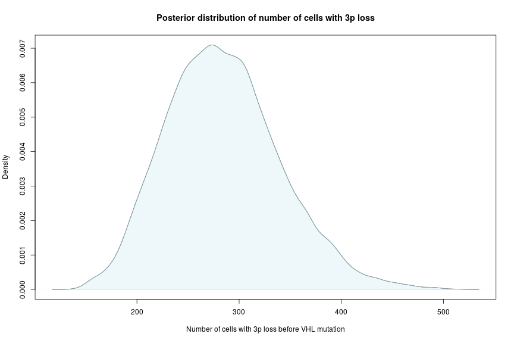

```r
age.in.dens <- density(age.inc.gs[[11]][rcc.burn.in:rcc.iters] / vhl.driver.mutation.rate)
plot(age.in.dens, xlab = "Number of cells with 3p loss before VHL mutation", ylab="Density", main = "Posterior distribution of number of cells with 3p loss")
# polygon(age.in.dens, col="lightblue", border="black")
polygon(age.in.dens, col=adjustcolor("lightblue",alpha.f=0.2), border=adjustcolor("lightblue",alpha.f=0.8))
```

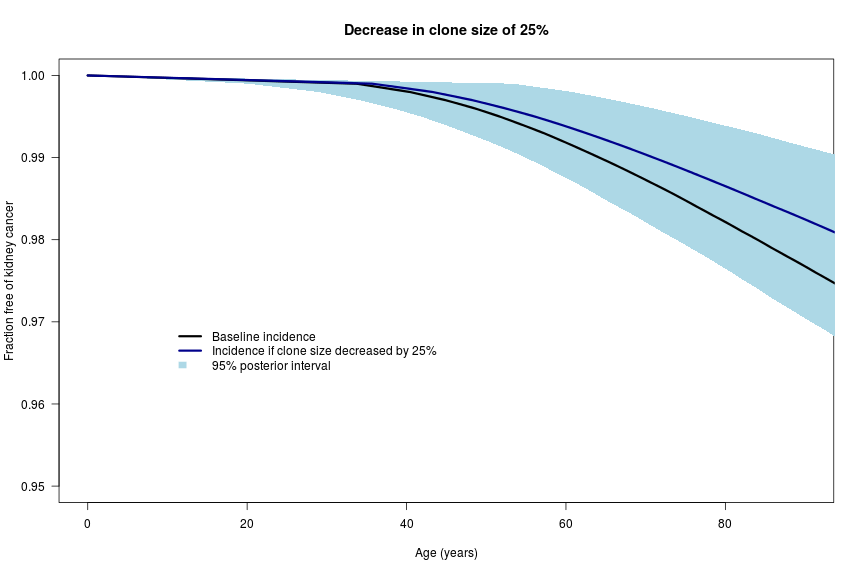

```r
post.less0 <- apply(age.inc.gs[[12]][,(rcc.burn.in+1):rcc.iters], MARGIN = 2, FUN=sort)
post.less0 <- t(apply(post.less0, MARGIN = 1, FUN=quantile, probs=c(0.025,0.5,0.975)))
baseline.survfit <- survfit(Surv(post.less0[,2], rep(1, length(post.less0[,2]))) ~ 1)

post.less25 <- apply(age.inc.gs[[13]][,(rcc.burn.in+1):rcc.iters], MARGIN = 2, FUN=sort)
post.less25 <- t(apply(post.less25, MARGIN = 1, FUN=quantile, probs=c(0.025,0.5,0.975)))
less25.survfit.0.025 <- survfit(Surv(post.less25[,1], rep(1, length(post.less25[,1]))) ~ 1)
less25.survfit.0.5 <- survfit(Surv(post.less25[,2], rep(1, length(post.less25[,1]))) ~ 1)
less25.survfit.0.975 <- survfit(Surv(post.less25[,3], rep(1, length(post.less25[,1]))) ~ 1)
plot(NULL, xlim=c(0,90), ylim=c(0.95,1), xlab="Age (years)", ylab="Fraction free of kidney cancer", las=1, main="Decrease in clone size of 25%")
polygon(x=c(0,less25.survfit.0.025$time, rev(less25.survfit.0.975$time),0), y=c(1,less25.survfit.0.025$surv, rev(less25.survfit.0.975$surv),1), col="lightblue", border=NA)
lines(c(0,baseline.survfit$time), c(1,baseline.survfit$surv), lwd=3)
lines(c(0,less25.survfit.0.5$time), c(1,less25.survfit.0.5$surv), lwd=3, col="darkblue")
legend(10,0.97, lwd=c(3,3,0), col=c("black", "darkblue", NULL), fill=c(NA, NA, "lightblue"), border = "white", legend=c("Baseline incidence", "Incidence if clone size decreased by 25%", "95% posterior interval"), bty="n", merge=TRUE)
```

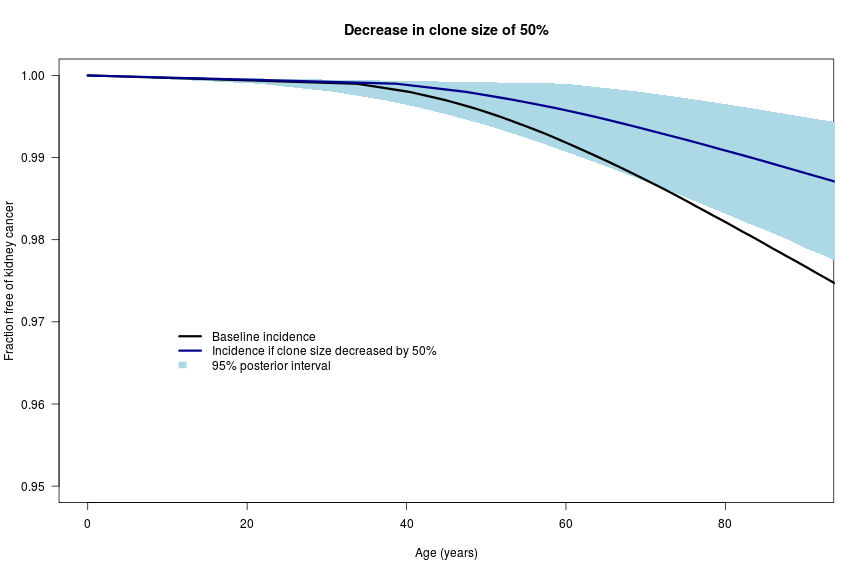

```r
post.less50 <- apply(age.inc.gs[[14]][,(rcc.burn.in+1):rcc.iters], MARGIN = 2, FUN=sort)
post.less50 <- t(apply(post.less50, MARGIN = 1, FUN=quantile, probs=c(0.025,0.5,0.975)))
less50.survfit.0.025 <- survfit(Surv(post.less50[,1], rep(1, length(post.less50[,1]))) ~ 1)
less50.survfit.0.5 <- survfit(Surv(post.less50[,2], rep(1, length(post.less50[,1]))) ~ 1)
less50.survfit.0.975 <- survfit(Surv(post.less50[,3], rep(1, length(post.less50[,1]))) ~ 1)
plot(NULL, xlim=c(0,90), ylim=c(0.95,1), xlab="Age (years)", ylab="Fraction free of kidney cancer", las=1, main="Decrease in clone size of 50%")
polygon(x=c(0,less50.survfit.0.025$time, rev(less50.survfit.0.975$time),0), y=c(1,less50.survfit.0.025$surv, rev(less50.survfit.0.975$surv),1), col="lightblue", border=NA)
lines(c(0,baseline.survfit$time), c(1,baseline.survfit$surv), lwd=3)
lines(c(0,less50.survfit.0.5$time), c(1,less50.survfit.0.5$surv), lwd=3, col="darkblue")
legend(10,0.97, lwd=c(3,3,0), col=c("black", "darkblue", NULL), fill=c(NA, NA, "lightblue"), border = "white", legend=c("Baseline incidence", "Incidence if clone size decreased by 50%", "95% posterior interval"), bty="n", merge=TRUE)
```

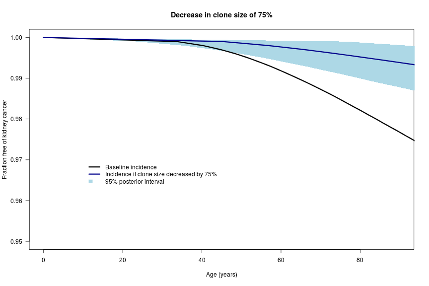

```r
post.less75 <- apply(age.inc.gs[[15]][,(rcc.burn.in+1):rcc.iters], MARGIN = 2, FUN=sort)
post.less75 <- t(apply(post.less75, MARGIN = 1, FUN=quantile, probs=c(0.025,0.5,0.975)))
less75.survfit.0.025 <- survfit(Surv(post.less75[,1], rep(1, length(post.less75[,1]))) ~ 1)
less75.survfit.0.5 <- survfit(Surv(post.less75[,2], rep(1, length(post.less75[,1]))) ~ 1)
less75.survfit.0.975 <- survfit(Surv(post.less75[,3], rep(1, length(post.less75[,1]))) ~ 1)
plot(NULL, xlim=c(0,90), ylim=c(0.95,1), xlab="Age (years)", ylab="Fraction free of kidney cancer", las=1, main="Decrease in clone size of 75%")
polygon(x=c(0,less75.survfit.0.025$time, rev(less75.survfit.0.975$time),0), y=c(1,less75.survfit.0.025$surv, rev(less75.survfit.0.975$surv),1), col="lightblue", border=NA)
lines(c(0,baseline.survfit$time), c(1,baseline.survfit$surv), lwd=3)
lines(c(0,less75.survfit.0.5$time), c(1,less75.survfit.0.5$surv), lwd=3, col="darkblue")
legend(10,0.97, lwd=c(3,3,0), col=c("black", "darkblue", NULL), fill=c(NA, NA, "lightblue"), border = "white", legend=c("Baseline incidence", "Incidence if clone size decreased by 75%", "95% posterior interval"), bty="n", merge=TRUE)
```

## Versioning notes

```r
Sys.time()
```

```
## [1] "2017-06-16 13:45:15 BST"
```